# ¿Podemos confiar en el tiempo promedio de desplazamiento urbano?

Autor/a

Alay Erick y Durán John

Fecha de publicación

18 de noviembre de 2026

## 1 Resumen ejecutivo

Se analizaron 1304 viajes válidos de todos los medios de transporte, con el fin de definir un tiempo de referencia para planificación. Los tiempos son asimétricos: la media es 39.1 min y la mediana 32.8 min, porque unos pocos viajes con congestión extrema elevan el promedio. Se recomienda usar la **mediana (32.8 min; IC 90 % bootstrap: 32 a 33.8 min)** como tiempo de un viaje típico y el percentil 90 (68.2 min) como referencia de planificación para evitar subestimar los viajes lentos. La cifra es válida solo para viajes registrados con duración válida, no necesariamente para todos los desplazamientos de la ciudad.

## 2 Clasificación de variables y diagnóstico de lectura

Al ejecutar `str(base)`, se observa que el conjunto de datos cuenta con **1.365 registros y 9 variables**, y que **R asignó el tipo `chr` (cadena de texto) a todas las columnas sin excepción**. Esto ocurre porque la presencia de unidades de medida escritas, formatos mixtos, espacios adicionales y texto no numérico impidió que R reconociera automáticamente las variables numéricas o temporales.

| Variable | Qué representa | Tipo estadístico | Escala de medición | Tipo detectado por R |
| --- | --- | --- | --- | --- |
| `id_viaje` | Identificador único del viaje (`VIA-00001`) | Identificador (Cualitativa) | Nominal | `chr` |
| `fecha` | Fecha del desplazamiento | Temporal / Cuantitativa discreta | Intervalo | `chr` |
| `zona_origen` | Sector de origen (Norte, Sur, Centro, Valle) | Cualitativa | Nominal | `chr` |
| `zona_destino` | Sector de destino (Norte, Sur, Centro, Valle) | Cualitativa | Nominal | `chr` |
| `medio_transporte` | Modo de transporte utilizado | Cualitativa | Nominal | `chr` |
| `hora_salida` | Hora de inicio del trayecto | Temporal / Categórica | Intervalo / Nominal | `chr` |
| `tiempo_viaje` | Duración del trayecto en minutos (variable principal) | Cuantitativa continua | Razón | `chr` |
| `evaluo` | Indica si el usuario calificó el viaje (sí/no) | Cualitativa (Binaria) | Nominal | `chr` |
| `calificacion` | Valoración del viaje (1 a 5; vacía si no calificó) | Cualitativa (o discreta acotada) | Ordinal | `chr` |

**Columnas leídas como texto (`chr`) que requieren conversión para su análisis:**

- **`tiempo_viaje` (debe ser numérica / `numeric`):** R la importó como texto porque mezcla números con coma decimal (`"33,0"`), unidades explícitas (`"49,1 min"`), equivalencias en horas y palabras como `"pendiente"`.
- **`calificacion` (debe ser numérica entera / ordinal):** Aunque representa una escala del 1 al 5, R la leyó como `chr` debido a valores no numéricos o mal formateados en la columna (se detectan cadenas de hasta 13 caracteres en `summary()`), además de 712 valores `NA`.
- **`fecha` (debe ser fecha / `Date`):** Se leyó como `chr` porque combina distintos formatos de calendario (`"27/07/2026"` en formato `DD/MM/YYYY` y `"2025-10-28"` en formato `YYYY-MM-DD`), además de contener 11 valores faltantes explícitos.
- **`hora_salida` (debe procesarse como tiempo / franja horaria):** Ingresó como `chr` al mezclar formatos de 24 horas (`"17:10"`), formatos de 12 horas con AM/PM (`"8:00 PM"`) y separadores textuales (`"20h55"`).

## 3 Limpieza y control de calidad de los datos

Para garantizar la reproducibilidad y mantener el proyecto modular, el proceso de depuración se ejecuta mediante el script `src/preprocesar.R`, el cual estandariza categorías, normaliza formatos temporales y convierte la variable principal (`tiempo_viaje`) a minutos.

### 3.1 Registro de problemas detectados y decisiones de limpieza

En la siguiente tabla se documentan todas las anomalías identificadas en `viajes_raw.csv`, la cantidad de registros afectados, la acción tomada y su sustento metodológico:

| Variable(s) | Problema detectado | Filas afectadas | Decisión tomada | Justificación |
| --- | --- | --- | --- | --- |
| Todas / `id_viaje` | Registros duplicados exactos o repetidos por identificador (`VIA-XXXXX`). | 19 | **Excluir** duplicados conservando la primera ocurrencia. | Evita el sobrepeso artificial de trayectos repetidos en los estadísticos. |
| `zona_origen`, `zona_destino`, `medio_transporte`, `evaluo` | Inconsistencia de mayúsculas, minúsculas, espacios en blanco, tildes (`automovil` vs `Automóvil`) y variantes (`sí`, `s`, `no`, `NO`). | 1.346 (todas estandarizadas) | **Corregir / Normalizar** a minúsculas sin tildes ni espacios; unificar `evaluo` en `"si"` / `"no"`. | Permite agrupar correctamente las categorías sin fragmentar los conteos. |
| `fecha` | Mezcla de formatos (`DD/MM/YYYY`, `YYYY-MM-DD`), 11 `NA` originales y 11 fechas imposibles o textuales (`"31/02/2026"`, `"2026-13-04"`, `"fecha desconocida"`). | 22 (`NA` totales) | **Convertir** a formato `Date` (`fecha_limpia`); asignar `NA` a fechas inexistentes sin eliminar el registro. | Se preserva la información válida de duración del viaje aunque no se conozca la fecha exacta. |
| `hora_salida` | Mezcla de formatos de 24h (`17:10`), 12h (`8:00 PM`) y separador literal (`20h55`). | 1.346 (normalizadas) | **Corregir / Convertir** a escala numérica continua (`hora_decimal`, 0 a 24 h) sin pérdida de casos (0 inválidas). | Unifica la representación horaria para analizar patrones por franja del día. |
| `tiempo_viaje` | Unidades mezcladas (números sin sufijo, `"min"`, `"minutos"`, `"h"`, `"horas"`), comas decimales, 14 `NA` originales y 15 textos no numéricos (`"pendiente"`). | 29 sin valor numérico | **Normalizar** todo a minutos (`viaje_min`); valores sin unidad se asumen en minutos y horas se multiplican por 60. Los 29 no numéricos pasan a `NA` y se **excluyen** del análisis. | Estandariza la variable principal en una única escala de razón; sin duración válida no es posible calcular el indicador. |
| `tiempo_viaje` (`viaje_min`) | Duraciones negativas o iguales a cero (`<= 0` minutos). | 13 | **Excluir** de la población analítica. | Un desplazamiento urbano real no puede tener duración nula ni negativa; corresponden a errores de captura. |
| `tiempo_viaje` (`viaje_min`) | Valores extremos superiores a 180 minutos (7 casos entre 195,6 y 265,8 min en bus, automóvil y motocicleta). | 7 | **Conservar** en la población analítica. | Representan escenarios plausibles de congestión severa, cierres viales o incidentes reales; eliminarlos sesgaría a la baja la variabilidad real. |
| `calificacion` | Valores fuera del rango 1–5 o texto (`"0"`, `"6"`, `"sin calificar"`), además de 704 viajes no evaluados (`NA`). | 4 inválidos | **Corregir** asignando `NA` a los 4 valores fuera de escala y convertir a factor ordinal (`1` a `5`). | Mantiene la integridad de la escala ordinal sin descartar la duración del viaje asociado. |

### 3.2 Trazabilidad de registros (flujo de depuración)

Tras guardar la base depurada completa en `data/processed/viajes.csv` (1.346 registros), se define la **población analítica** incluyendo **todos los medios de transporte** (`automovil`, `bus`, `bicicleta` y `motocicleta`) con duración estrictamente positiva y válida (`viaje_min > 0`), ya que la consulta busca un indicador general de movilidad urbana de la ciudad (que posteriormente se desagregará por medio para evaluar diferencias estructurales):

- **Base cruda inicial (`viajes_raw.csv`):** 1365 registros.
- **Registros eliminados por duplicidad:** 19 registros (quedan 1346 viajes únicos en `data/processed/viajes.csv`).
- **Registros excluidos por duración faltante o no numérica (`NA` / `"pendiente"`):** 29 registros.
- **Registros excluidos por duración inválida (`<= 0` min):** 13 registros.
- **Población analítica final (`base_analitica`):** **1304 registros válidos** (95.5% del total inicial).

## 4 Análisis descriptivo de la duración de viaje

Para el análisis estadístico se define explícitamente la **población analítica** (`base_analisis`) como todos los viajes únicos con origen identificado y duración estrictamente positiva y válida (`viaje_min > 0`), abarcando la totalidad de los medios de transporte registrados en la ciudad (1304 trayectos).

Estadísticos descriptivos de tiempo_viaje (en minutos)

| n | Media | Mediana | DE | Q1 | Q3 | IQR | Minimo | Maximo |
| --- | --- | --- | --- | --- | --- | --- | --- | --- |
| 1304 | 39.05 | 32.8 | 27.59 | 23.3 | 47.62 | 24.32 | 0.18 | 265.8 |

```
Umbral superior de Tukey (Q3 + 1.5*IQR): 84.11 min | Casos atípicos: 76
```

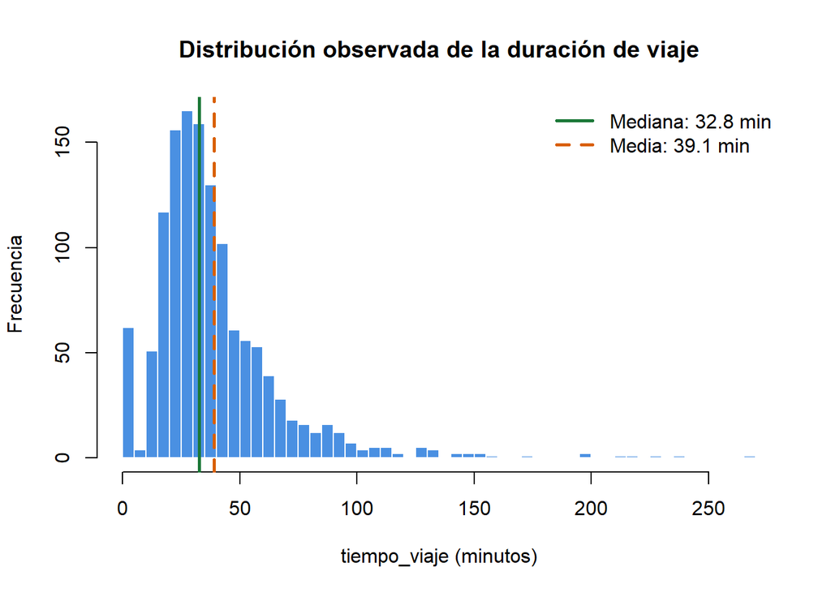

Figura 1: Distribución de la variable principal (tiempo_viaje en minutos)

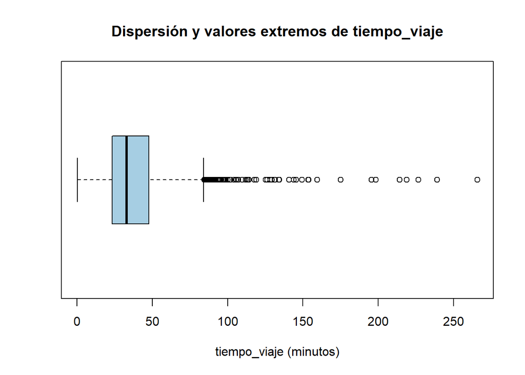

Figura 2: Diagrama de caja de la variable principal (tiempo_viaje en minutos)

**Interpretación de la distribución, asimetría y valores extremos**

A partir de los estadísticos y representaciones gráficas (Figura 1 y Figura 2), se extraen las siguientes conclusiones sobre el comportamiento de `tiempo_viaje`:

- **Relación entre la media y la mediana:** La **media (39.05 min) es considerablemente mayor que la mediana (32.8 min)**, con una diferencia de 6.25 minutos. Esto confirma una **asimetría positiva (sesgo hacia la derecha)**: mientras que la mayoría de los desplazamientos se concentran en duraciones bajas y moderadas, existe una cola larga de viajes muy prolongados que arrastran el promedio hacia arriba sin alterar el valor central.
- **Plausibilidad de los valores atípicos:** Aplicando el criterio de Tukey ($Q_3 + 1.5 \times \text{IQR} = 84.11\text{ min}$), se identifican **76 observaciones atípicas** en el extremo superior (alcanzando hasta 265.8 minutos). Lejos de ser errores de digitación, estos registros son **casos plausibles** dentro de la dinámica urbana: reflejan eventos reales de congestión vehicular severa, horas pico, accidentes de tránsito o trayectos interzonales largos en transporte público o bicicleta.
- **Medida más adecuada para describir un caso típico:** La **mediana (32.8 min)**, acompañada del **rango intercuartílico ($\text{IQR} = 24.32\text{ min}$, entre 23.3 y 47.6 min)**, describe mucho mejor un desplazamiento típico. Al ser estadísticos resistentes a valores extremos, no se distorsionan por episodios aislados de congestión extrema y reflejan con fidelidad lo que experimenta el 50 % central de los usuarios.
- **Información que se pierde al resumir en una sola cifra:** Condensar todos los viajes en un único número oculta la **heterogeneidad estructural** del sistema de transporte: se pierde la noción de dispersión y riesgo de retraso (incertidumbre), así como las diferencias críticas según el **medio de transporte utilizado** (bicicleta vs. automóvil o bus), la **franja horaria** (hora pico vs. valle) y la distancia entre zonas de origen y destino.

## 5 Simulación de muestreo y análisis de sesgo

Para evaluar cómo el método de recolección de datos afecta la estimación del tiempo promedio de viaje, se toma como parámetro de referencia la media de la población analítica ($\mu = 39.05\text{ min}$) y se comparan 500 muestras de tamaño $n = 100$ bajo tres esquemas: muestreo aleatorio simple, muestreo autoseleccionado (usuarios que evaluaron el viaje) y muestreo estratificado con asignación igualitaria por `zona_origen` (25 registros por sector).

Comparación de medias muestrales frente al parámetro poblacional (500 réplicas)

| Procedimiento | Media_estimada | Sesgo_vs_mu | Error_estandar |
| --- | --- | --- | --- |
| Población analítica (referencia) | 39.05 | 0.00 | 0.00 |
| Aleatorio simple (n = 100) | 38.85 | -0.20 | 2.61 |
| Solo seleccionados (evaluo = ‘si’) | 48.80 | 9.75 | 2.85 |
| Estratificado igualitario (25 por zona) | 38.80 | -0.25 | 2.53 |

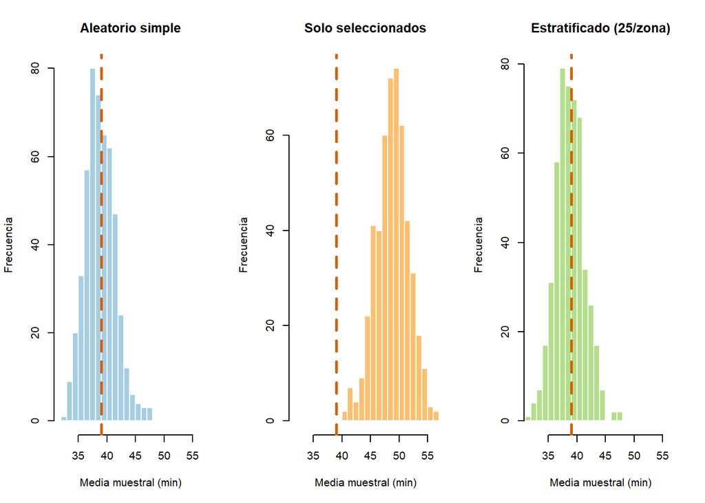

Figura 3: Comparación de distribuciones de medias por procedimiento de muestreo

**Interpretación del sesgo de selección, estratificación y representatividad**

## 6 Teorema del límite central y error estándar

Para evaluar cómo se comporta la media muestral cuando la variable original presenta una fuerte asimetría hacia la derecha, se aplica el **Teorema del Límite Central (TLC)**. Teóricamente, la precisión de la media muestral se mide a través del **error estándar** ($\text{SE}$), definido mediante la ecuación:

$$\text{SE}(\bar{X}) = \frac{\sigma}{\sqrt{n}} \approx \frac{s}{\sqrt{n}}$$

donde $\sigma$ (estimada por la desviación estándar muestral $s$) representa la variabilidad de los viajes individuales y $n$ es el tamaño de cada muestra.

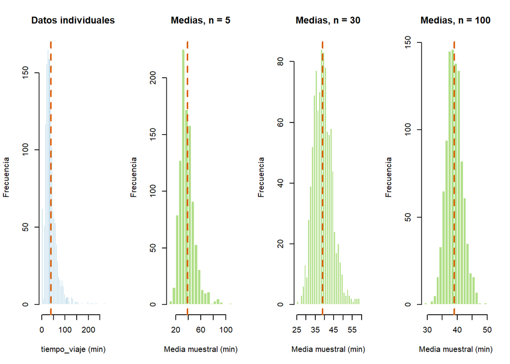

Figura 4: Distribución de los datos individuales frente a la distribución de medias muestrales para n = 5, 30 y 100 (1.000 réplicas)

Comparación entre error estándar teórico y empírico

| Indicador | Valor_minutos |
| --- | --- |
| Error estándar teórico (n = 50) | 3.902 |
| Error estándar empírico (2.000 réplicas, n = 50) | 3.772 |
| Error estándar teórico (n = 25) | 5.518 |
| Error estándar teórico cuadruplicando tamaño (n = 100) | 2.759 |

**Interpretación del comportamiento asintótico y precisión de la media**

A partir de la Figura 4 y de los cálculos de error estándar, se responden las interrogantes clave sobre la inferencia de la media:

- **Forma de los datos individuales vs. distribución de las medias al crecer $n$:** Los viajes individuales (`Datos individuales`) exhiben una marcada **asimetría positiva** (sesgo a la derecha), con una cola extensa provocada por trayectos con congestión extrema. Sin embargo, conforme aumenta el tamaño muestral ($n = 5 \rightarrow 30 \rightarrow 100$), la distribución de las medias muestrales se vuelve progresivamente **más simétrica, acampanada (normal) y estrecha** alrededor de $\mu = 39.05\text{ min}$. Con $n = 5$ aún persiste cierto sesgo heredado de los valores extremos, pero a partir de $n = 30$ y especialmente en $n = 100$, el Teorema del Límite Central garantiza una aproximación normal muy limpia.
- **Coincidencia entre el error estándar teórico y el empírico:** Para muestras de tamaño $n = 50$, el valor obtenido por fórmula ($\text{SE}_{\text{fórmula}} = 3.902\text{ min}$) y la desviación estándar de las 2.000 medias simuladas ($\text{SE}_{\text{empírico}} = 3.772\text{ min}$) **coinciden casi exactamente** (diferencia de apenas $0.13\text{ min}$), validando empíricamente la expresión $\sigma / \sqrt{n}$.
- **Efecto de cuadruplicar el tamaño muestral ($n$):** Dado que $n$ está dentro de una raíz cuadrada en el denominador, **cuadruplicar el tamaño de la muestra reduce el error estándar exactamente a la mitad** ($\sqrt{4n} = 2\sqrt{n}$). Por ejemplo, al pasar de $n = 25$ ($\text{SE} = 5.518\text{ min}$) a $n = 100$ ($\text{SE} = 2.759\text{ min}$), la incertidumbre de la media disminuye en un 50 %.
- **Diferencia entre desviación estándar ($s$) y error estándar ($\text{SE}$):** La **desviación estándar ($s = 27.59\text{ min}$)** mide cuánto varían los *viajes individuales* entre sí (por ejemplo, la diferencia entre un trayecto rápido en bicicleta y uno lento en bus durante hora pico); este valor es una propiedad de la población y **no disminuye** al recoger más datos. En cambio, el **error estándar ($\text{SE}$)** mide la incertidumbre o variabilidad de la *media muestral* al repetir el muestreo, y **sí disminuye** conforme aumenta el tamaño de la muestra $n$.

## 7 Intervalos bootstrap y clásico, con interpretación

Para cuantificar la incertidumbre de la estimación se construyen intervalos de confianza del 90 % de dos formas: **bootstrap percentil** (2.000 remuestreos con reemplazo) y el **procedimiento clásico basado en la distribución $t$ de Student**. Primero se trabaja con una muestra aleatoria de $n = 40$ viajes (ejercicio de la guía) y luego con toda la población analítica para estimar la media, la mediana y el percentil 90, que son las tres cifras candidatas para la recomendación.

**Código**

```r
set.seed(123)

# 1. Muestra aleatoria de tamaño n = 40
muestra <- sample(x, 40)

# Bootstrap percentil con 2000 réplicas sobre la muestra de n = 40
boot <- replicate(2000, mean(sample(muestra, replace = TRUE)))
ic_boot <- as.numeric(quantile(boot, c(0.05, 0.95)))

# Intervalo clásico t de Student al 90 %
ic_t <- as.numeric(t.test(muestra, conf.level = 0.90)$conf.int)

# Efecto del nivel de confianza (99 %) y del tamaño muestral (n cuadruplicado = 160)
ic_t99 <- as.numeric(t.test(muestra, conf.level = 0.99)$conf.int)
muestra160 <- sample(x, 160)
ic_t160 <- as.numeric(t.test(muestra160, conf.level = 0.90)$conf.int)

# 2. Bootstrap sobre toda la población analítica (base de la recomendación)
boot_pob_media <- replicate(2000, mean(sample(x, replace = TRUE)))
ic_pob_media_90 <- as.numeric(quantile(boot_pob_media, c(0.05, 0.95)))

ic_pob_mediana_90 <- ic_res   # mismo bootstrap de la mediana usado en el resumen ejecutivo

boot_pob_p90 <- replicate(2000, as.numeric(quantile(sample(x, replace = TRUE), 0.90)))
ic_pob_p90_90 <- as.numeric(quantile(boot_pob_p90, c(0.05, 0.95)))

tabla_ic <- data.frame(
  Estimacion = c(
    "Media (muestra n = 40) — Bootstrap percentil 90 %",
    "Media (muestra n = 40) — Clásico t 90 %",
    "Media (muestra n = 40) — Clásico t 99 %",
    "Media (muestra n = 160) — Clásico t 90 %",
    paste0("Media (población N = ", length(x), ") — Bootstrap 90 %"),
    paste0("Mediana (población N = ", length(x), ") — Bootstrap 90 %"),
    paste0("Percentil 90 (población N = ", length(x), ") — Bootstrap 90 %")
  ),
  Puntual = round(c(mean(muestra), mean(muestra), mean(muestra), mean(muestra160),
                    mean(x), median(x), as.numeric(quantile(x, 0.90))), 2),
  Inferior = round(c(ic_boot[1], ic_t[1], ic_t99[1], ic_t160[1],
                     ic_pob_media_90[1], ic_pob_mediana_90[1], ic_pob_p90_90[1]), 2),
  Superior = round(c(ic_boot[2], ic_t[2], ic_t99[2], ic_t160[2],
                     ic_pob_media_90[2], ic_pob_mediana_90[2], ic_pob_p90_90[2]), 2),
  Anchura = round(c(diff(ic_boot), diff(ic_t), diff(ic_t99), diff(ic_t160),
                    diff(ic_pob_media_90), diff(ic_pob_mediana_90), diff(ic_pob_p90_90)), 2)
)

knitr::kable(tabla_ic, row.names = FALSE,
             col.names = c("Estimador y método", "Puntual (min)", "Límite inf. (min)",
                           "Límite sup. (min)", "Anchura (min)"))
```

Tabla 1: Intervalos de confianza del 90 % mediante bootstrap percentil y distribución t (muestra de n = 40 y población analítica completa).

| Estimador y método | Puntual (min) | Límite inf. (min) | Límite sup. (min) | Anchura (min) |
| --- | --- | --- | --- | --- |
| Media (muestra n = 40) — Bootstrap percentil 90 % | 34.43 | 28.88 | 40.00 | 11.12 |
| Media (muestra n = 40) — Clásico t 90 % | 34.43 | 28.69 | 40.17 | 11.48 |
| Media (muestra n = 40) — Clásico t 99 % | 34.43 | 25.20 | 43.66 | 18.46 |
| Media (muestra n = 160) — Clásico t 90 % | 39.01 | 36.04 | 41.97 | 5.94 |
| Media (población N = 1304) — Bootstrap 90 % | 39.05 | 37.79 | 40.32 | 2.53 |
| Mediana (población N = 1304) — Bootstrap 90 % | 32.80 | 32.00 | 33.80 | 1.80 |
| Percentil 90 (población N = 1304) — Bootstrap 90 % | 68.24 | 65.13 | 71.75 | 6.62 |

**Código**

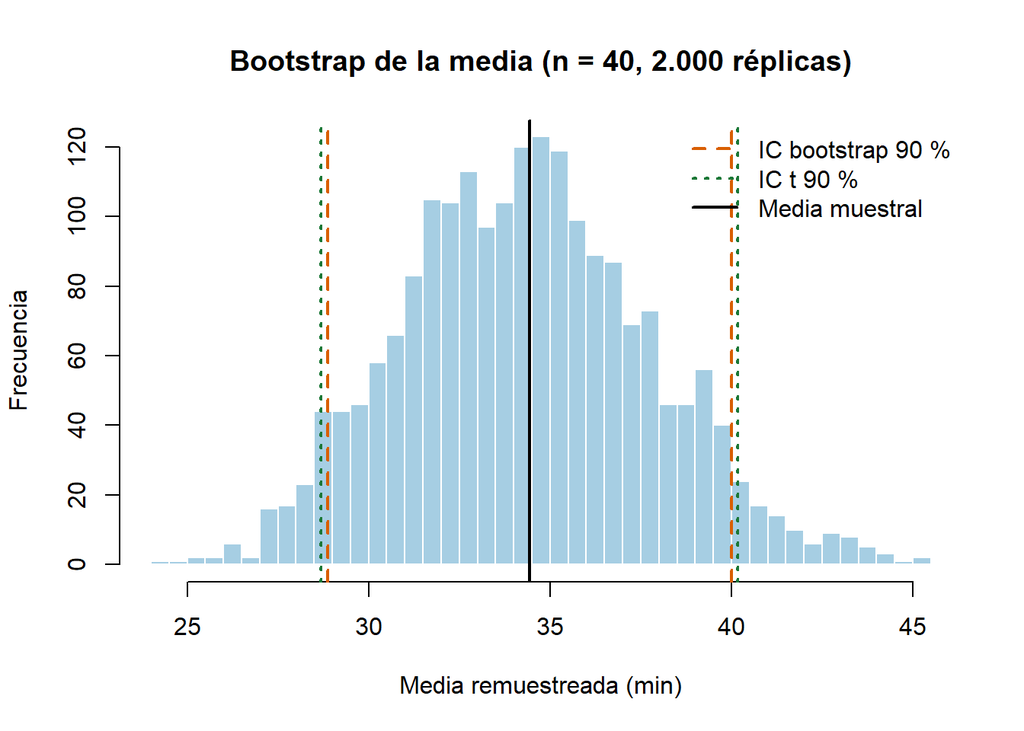

Figura 5: Distribución bootstrap de la media (muestra de n = 40) con los intervalos bootstrap y t del 90 %.

```r
hist(boot, breaks = 30, col = "#A6CEE3", border = "white",
     main = "Bootstrap de la media (n = 40, 2.000 réplicas)",
     xlab = "Media remuestreada (min)", ylab = "Frecuencia")
abline(v = ic_boot, col = "#D95F02", lwd = 2, lty = 2)
abline(v = ic_t, col = "#1B7837", lwd = 2, lty = 3)
abline(v = mean(muestra), col = "black", lwd = 2)
legend("topright", legend = c("IC bootstrap 90 %", "IC t 90 %", "Media muestral"),
       col = c("#D95F02", "#1B7837", "black"), lty = c(2, 3, 1), lwd = 2, bty = "n")
```

**Código**

```r
set.seed(123)

cobertura <- function(n, reps = 1000) {
  mean(replicate(reps, {
    ic <- t.test(sample(x, n), conf.level = 0.90)$conf.int
    ic[1] <= mu & mu <= ic[2]
  }))
}

tamanos_cob <- c(10, 30, 100)
cob_obs <- sapply(tamanos_cob, cobertura)

tabla_cob <- data.frame(
  n = tamanos_cob,
  Nominal = "90,0 %",
  Observada = paste0(round(cob_obs * 100, 1), " %")
)

knitr::kable(tabla_cob, row.names = FALSE,
             col.names = c("Tamaño muestral (n)", "Confianza nominal", "Cobertura empírica observada"))
cob_txt <- if (all(cob_obs >= 0.88)) {
  "se mantuvo cercana al 90 % nominal en los tres tamaños, por lo que el intervalo t resulta confiable en estos datos"
} else {
  "quedó por debajo del 90 % nominal en al menos un tamaño, lo que indica que la asimetría y los viajes extremos hacen que el intervalo t sea algo optimista con muestras pequeñas"
}
```

Tabla 2: Cobertura empírica del intervalo t del 90 % en 1.000 simulaciones por tamaño muestral.

| Tamaño muestral (n) | Confianza nominal | Cobertura empírica observada |
| --- | --- | --- |
| 10 | 90,0 % | 86.6 % |
| 30 | 90,0 % | 85.9 % |
| 100 | 90,0 % | 89.2 % |

Los intervalos se resumen en la Tabla 1 y en la Figura 5, y la verificación de su tasa de acierto en la Tabla 2.

**Interpretación.** Con la muestra de $n = 40$, el intervalo bootstrap del 90 % va de 28.88 a 40 min (anchura de 11.12 min) y el intervalo $t$ va de 28.69 a 40.17 min (anchura de 11.48 min); ambos son muy parecidos porque la media muestral, aun con datos asimétricos, tiene una distribución aproximadamente simétrica. Un nivel de confianza del 90 % tiene un sentido frecuentista: si se repitiera muchas veces el muestreo y se calculara cada vez el intervalo con el mismo procedimiento, cerca del 90 % de esos intervalos contendría la media poblacional $\mu = 39.05$ min. No equivale a decir que hay una probabilidad del 90 % de que $\mu$ esté dentro de un intervalo ya calculado: $\mu$ es un valor fijo y ese intervalo concreto la contiene o no la contiene. Al aumentar $n$ el error estándar disminuye y el intervalo se estrecha (con $n = 160$ la anchura del intervalo $t$ es 5.94 min frente a 11.48 min con $n = 40$), mientras que exigir 99 % de confianza lo ensancha (18.46 min con $n = 40$), porque se usa un valor crítico mayor a cambio de más seguridad. Finalmente, la cobertura observada quedó por debajo del 90 % nominal en al menos un tamaño, lo que indica que la asimetría y los viajes extremos hacen que el intervalo t sea algo optimista con muestras pequeñas (86.6 %, 85.9 % y 89.2 % con $n = 10$, $30$ y $100$).